# Risk Factor Analysis

## Outcome Variable

**Outcome Variable:** wasted

## Predictor Variables

**Intervention Variable:** birthlen

**Adjustment Set:**

- arm
- sex
- W_mage
- meducyrs
- feducyrs
- vagbrth
- single
- brthmon
- W_parity
- delta_W_mage
- delta_meducyrs
- delta_feducyrs
- delta_vagbrth
- delta_single
- delta_brthmon
- delta_W_parity

## Stratifying Variables

The analysis was stratified on these variable(s):

- agecat
- studyid
- country

## Data Summary

| agecat | studyid | country | birthlen | wasted | n_cell | n |
| --- | --- | --- | --- | --- | --- | --- |
| Birth | ki0047075b-MAL-ED | BANGLADESH | >=50 cm | 0 | 30 | 215 |
| Birth | ki0047075b-MAL-ED | BANGLADESH | >=50 cm | 1 | 9 | 215 |
| Birth | ki0047075b-MAL-ED | BANGLADESH | <48 cm | 0 | 81 | 215 |
| Birth | ki0047075b-MAL-ED | BANGLADESH | <48 cm | 1 | 16 | 215 |
| Birth | ki0047075b-MAL-ED | BANGLADESH | [48-50) cm | 0 | 68 | 215 |
| Birth | ki0047075b-MAL-ED | BANGLADESH | [48-50) cm | 1 | 11 | 215 |
| Birth | ki0047075b-MAL-ED | BRAZIL | >=50 cm | 0 | 30 | 62 |
| Birth | ki0047075b-MAL-ED | BRAZIL | >=50 cm | 1 | 0 | 62 |
| Birth | ki0047075b-MAL-ED | BRAZIL | <48 cm | 0 | 13 | 62 |
| Birth | ki0047075b-MAL-ED | BRAZIL | <48 cm | 1 | 1 | 62 |
| Birth | ki0047075b-MAL-ED | BRAZIL | [48-50) cm | 0 | 17 | 62 |
| Birth | ki0047075b-MAL-ED | BRAZIL | [48-50) cm | 1 | 1 | 62 |
| Birth | ki0047075b-MAL-ED | INDIA | >=50 cm | 0 | 8 | 45 |
| Birth | ki0047075b-MAL-ED | INDIA | >=50 cm | 1 | 1 | 45 |
| Birth | ki0047075b-MAL-ED | INDIA | <48 cm | 0 | 16 | 45 |
| Birth | ki0047075b-MAL-ED | INDIA | <48 cm | 1 | 2 | 45 |
| Birth | ki0047075b-MAL-ED | INDIA | [48-50) cm | 0 | 16 | 45 |
| Birth | ki0047075b-MAL-ED | INDIA | [48-50) cm | 1 | 2 | 45 |
| Birth | ki0047075b-MAL-ED | NEPAL | >=50 cm | 0 | 8 | 26 |
| Birth | ki0047075b-MAL-ED | NEPAL | >=50 cm | 1 | 0 | 26 |
| Birth | ki0047075b-MAL-ED | NEPAL | <48 cm | 0 | 9 | 26 |
| Birth | ki0047075b-MAL-ED | NEPAL | <48 cm | 1 | 2 | 26 |
| Birth | ki0047075b-MAL-ED | NEPAL | [48-50) cm | 0 | 7 | 26 |
| Birth | ki0047075b-MAL-ED | NEPAL | [48-50) cm | 1 | 0 | 26 |
| Birth | ki0047075b-MAL-ED | PERU | >=50 cm | 0 | 51 | 228 |
| Birth | ki0047075b-MAL-ED | PERU | >=50 cm | 1 | 1 | 228 |
| Birth | ki0047075b-MAL-ED | PERU | <48 cm | 0 | 81 | 228 |
| Birth | ki0047075b-MAL-ED | PERU | <48 cm | 1 | 2 | 228 |
| Birth | ki0047075b-MAL-ED | PERU | [48-50) cm | 0 | 91 | 228 |
| Birth | ki0047075b-MAL-ED | PERU | [48-50) cm | 1 | 2 | 228 |

[output cut: 426 more lines]

The following strata were considered:

- agecat: 24 months, studyid: ki0047075b-MAL-ED, country: BANGLADESH
- agecat: 24 months, studyid: ki0047075b-MAL-ED, country: BRAZIL
- agecat: 24 months, studyid: ki0047075b-MAL-ED, country: INDIA
- agecat: 24 months, studyid: ki0047075b-MAL-ED, country: NEPAL
- agecat: 24 months, studyid: ki0047075b-MAL-ED, country: PERU
- agecat: 24 months, studyid: ki0047075b-MAL-ED, country: SOUTH AFRICA
- agecat: 24 months, studyid: ki0047075b-MAL-ED, country: TANZANIA, UNITED REPUBLIC OF
- agecat: 24 months, studyid: ki1000108-CMC-V-BCS-2002, country: INDIA
- agecat: 24 months, studyid: ki1000108-IRC, country: INDIA
- agecat: 24 months, studyid: ki1000109-EE, country: PAKISTAN
- agecat: 24 months, studyid: ki1017093-NIH-Birth, country: BANGLADESH
- agecat: 24 months, studyid: ki1017093b-PROVIDE, country: BANGLADESH
- agecat: 24 months, studyid: ki1017093c-NIH-Crypto, country: BANGLADESH
- agecat: 24 months, studyid: ki1101329-Keneba, country: GAMBIA
- agecat: 24 months, studyid: ki1113344-GMS-Nepal, country: NEPAL
- agecat: 24 months, studyid: ki1114097-CMIN, country: BANGLADESH
- agecat: 24 months, studyid: ki1114097-CONTENT, country: PERU
- agecat: 24 months, studyid: ki1119695-PROBIT, country: BELARUS
- agecat: 24 months, studyid: ki1126311-ZVITAMBO, country: ZIMBABWE
- agecat: 24 months, studyid: ki1135781-COHORTS, country: GUATEMALA
- agecat: 24 months, studyid: ki1135781-COHORTS, country: INDIA
- agecat: 24 months, studyid: ki1135781-COHORTS, country: PHILIPPINES
- agecat: 24 months, studyid: kiGH5241-JiVitA-3, country: BANGLADESH
- agecat: 24 months, studyid: kiGH5241-JiVitA-4, country: BANGLADESH
- agecat: 6 months, studyid: ki0047075b-MAL-ED, country: BANGLADESH
- agecat: 6 months, studyid: ki0047075b-MAL-ED, country: BRAZIL
- agecat: 6 months, studyid: ki0047075b-MAL-ED, country: INDIA
- agecat: 6 months, studyid: ki0047075b-MAL-ED, country: NEPAL
- agecat: 6 months, studyid: ki0047075b-MAL-ED, country: PERU
- agecat: 6 months, studyid: ki0047075b-MAL-ED, country: SOUTH AFRICA
- agecat: 6 months, studyid: ki0047075b-MAL-ED, country: TANZANIA, UNITED REPUBLIC OF
- agecat: 6 months, studyid: ki1000108-CMC-V-BCS-2002, country: INDIA
- agecat: 6 months, studyid: ki1000108-IRC, country: INDIA
- agecat: 6 months, studyid: ki1000109-EE, country: PAKISTAN
- agecat: 6 months, studyid: ki1000109-ResPak, country: PAKISTAN
- agecat: 6 months, studyid: ki1000304b-SAS-CompFeed, country: INDIA
- agecat: 6 months, studyid: ki1017093-NIH-Birth, country: BANGLADESH
- agecat: 6 months, studyid: ki1017093b-PROVIDE, country: BANGLADESH
- agecat: 6 months, studyid: ki1017093c-NIH-Crypto, country: BANGLADESH
- agecat: 6 months, studyid: ki1101329-Keneba, country: GAMBIA
- agecat: 6 months, studyid: ki1113344-GMS-Nepal, country: NEPAL
- agecat: 6 months, studyid: ki1114097-CMIN, country: BANGLADESH
- agecat: 6 months, studyid: ki1114097-CONTENT, country: PERU
- agecat: 6 months, studyid: ki1119695-PROBIT, country: BELARUS
- agecat: 6 months, studyid: ki1126311-ZVITAMBO, country: ZIMBABWE
- agecat: 6 months, studyid: ki1135781-COHORTS, country: GUATEMALA
- agecat: 6 months, studyid: ki1135781-COHORTS, country: INDIA
- agecat: 6 months, studyid: ki1135781-COHORTS, country: PHILIPPINES
- agecat: 6 months, studyid: kiGH5241-JiVitA-3, country: BANGLADESH
- agecat: 6 months, studyid: kiGH5241-JiVitA-4, country: BANGLADESH
- agecat: Birth, studyid: ki0047075b-MAL-ED, country: BANGLADESH
- agecat: Birth, studyid: ki0047075b-MAL-ED, country: BRAZIL
- agecat: Birth, studyid: ki0047075b-MAL-ED, country: INDIA
- agecat: Birth, studyid: ki0047075b-MAL-ED, country: NEPAL
- agecat: Birth, studyid: ki0047075b-MAL-ED, country: PERU
- agecat: Birth, studyid: ki0047075b-MAL-ED, country: SOUTH AFRICA
- agecat: Birth, studyid: ki0047075b-MAL-ED, country: TANZANIA, UNITED REPUBLIC OF
- agecat: Birth, studyid: ki1000108-CMC-V-BCS-2002, country: INDIA
- agecat: Birth, studyid: ki1000108-IRC, country: INDIA
- agecat: Birth, studyid: ki1000109-EE, country: PAKISTAN
- agecat: Birth, studyid: ki1000109-ResPak, country: PAKISTAN
- agecat: Birth, studyid: ki1000304b-SAS-CompFeed, country: INDIA
- agecat: Birth, studyid: ki1017093-NIH-Birth, country: BANGLADESH
- agecat: Birth, studyid: ki1017093b-PROVIDE, country: BANGLADESH
- agecat: Birth, studyid: ki1017093c-NIH-Crypto, country: BANGLADESH
- agecat: Birth, studyid: ki1101329-Keneba, country: GAMBIA
- agecat: Birth, studyid: ki1113344-GMS-Nepal, country: NEPAL
- agecat: Birth, studyid: ki1114097-CMIN, country: BANGLADESH
- agecat: Birth, studyid: ki1114097-CONTENT, country: PERU
- agecat: Birth, studyid: ki1119695-PROBIT, country: BELARUS
- agecat: Birth, studyid: ki1126311-ZVITAMBO, country: ZIMBABWE
- agecat: Birth, studyid: ki1135781-COHORTS, country: GUATEMALA
- agecat: Birth, studyid: ki1135781-COHORTS, country: INDIA
- agecat: Birth, studyid: ki1135781-COHORTS, country: PHILIPPINES
- agecat: Birth, studyid: kiGH5241-JiVitA-3, country: BANGLADESH
- agecat: Birth, studyid: kiGH5241-JiVitA-4, country: BANGLADESH

### Dropped Strata

Some strata were dropped due to rare outcomes:

- agecat: Birth, studyid: ki0047075b-MAL-ED, country: BRAZIL
- agecat: Birth, studyid: ki0047075b-MAL-ED, country: INDIA
- agecat: Birth, studyid: ki0047075b-MAL-ED, country: NEPAL
- agecat: Birth, studyid: ki0047075b-MAL-ED, country: PERU
- agecat: Birth, studyid: ki0047075b-MAL-ED, country: SOUTH AFRICA
- agecat: Birth, studyid: ki0047075b-MAL-ED, country: TANZANIA, UNITED REPUBLIC OF
- agecat: Birth, studyid: ki1000108-CMC-V-BCS-2002, country: INDIA
- agecat: Birth, studyid: ki1000109-EE, country: PAKISTAN
- agecat: Birth, studyid: ki1000109-ResPak, country: PAKISTAN
- agecat: Birth, studyid: ki1114097-CMIN, country: BANGLADESH
- agecat: Birth, studyid: ki1114097-CONTENT, country: PERU
- agecat: Birth, studyid: ki1119695-PROBIT, country: BELARUS
- agecat: 6 months, studyid: ki0047075b-MAL-ED, country: BANGLADESH
- agecat: 6 months, studyid: ki0047075b-MAL-ED, country: BRAZIL
- agecat: 6 months, studyid: ki0047075b-MAL-ED, country: INDIA
- agecat: 6 months, studyid: ki0047075b-MAL-ED, country: NEPAL
- agecat: 6 months, studyid: ki0047075b-MAL-ED, country: PERU
- agecat: 6 months, studyid: ki0047075b-MAL-ED, country: SOUTH AFRICA
- agecat: 6 months, studyid: ki0047075b-MAL-ED, country: TANZANIA, UNITED REPUBLIC OF
- agecat: 6 months, studyid: ki1000108-CMC-V-BCS-2002, country: INDIA
- agecat: 6 months, studyid: ki1000109-EE, country: PAKISTAN
- agecat: 6 months, studyid: ki1000109-ResPak, country: PAKISTAN
- agecat: 6 months, studyid: ki1017093b-PROVIDE, country: BANGLADESH
- agecat: 6 months, studyid: ki1017093c-NIH-Crypto, country: BANGLADESH
- agecat: 6 months, studyid: ki1114097-CMIN, country: BANGLADESH
- agecat: 6 months, studyid: ki1114097-CONTENT, country: PERU
- agecat: 6 months, studyid: ki1119695-PROBIT, country: BELARUS
- agecat: 6 months, studyid: ki1135781-COHORTS, country: GUATEMALA
- agecat: 24 months, studyid: ki0047075b-MAL-ED, country: BANGLADESH
- agecat: 24 months, studyid: ki0047075b-MAL-ED, country: BRAZIL
- agecat: 24 months, studyid: ki0047075b-MAL-ED, country: INDIA
- agecat: 24 months, studyid: ki0047075b-MAL-ED, country: NEPAL
- agecat: 24 months, studyid: ki0047075b-MAL-ED, country: PERU
- agecat: 24 months, studyid: ki0047075b-MAL-ED, country: SOUTH AFRICA
- agecat: 24 months, studyid: ki0047075b-MAL-ED, country: TANZANIA, UNITED REPUBLIC OF
- agecat: 24 months, studyid: ki1000108-CMC-V-BCS-2002, country: INDIA
- agecat: 24 months, studyid: ki1000109-EE, country: PAKISTAN
- agecat: 24 months, studyid: ki1114097-CMIN, country: BANGLADESH
- agecat: 24 months, studyid: ki1114097-CONTENT, country: PERU
- agecat: 24 months, studyid: ki1119695-PROBIT, country: BELARUS
- agecat: 24 months, studyid: ki1135781-COHORTS, country: GUATEMALA

## Methods Detail

We’re interested in the causal parameters $E[Y_a]$ for all values of $a \in \mathcal{A}$. These parameters represent the mean outcome if, possibly contrary to fact, we intervened to set all units to have $A=a$. Under the randomization and positivity assumptions, these are identified by the statistical parameters $\psi_a=E_W[E_{Y|A,W}(Y|A=a,W)]$. In addition, we’re interested in the mean of $Y$, $E[Y]$ under no intervention (the observed mean). We will estimate these parameters by using SuperLearner to fit the relevant likelihood factors – $E_{Y|A,W}(Y|A=a,W)$ and $p(A=a|W)$, and then updating our likelihood fit using a joint TMLE.

For unadjusted analyses ($W=\{\}$), initial likelihoods were estimated using Lrnr_glm to estimate the simple $E(Y|A)$ and Lrnr_mean to estimate $p(A)$. For adjusted analyses, a small library containing Lrnr_glmnet, Lrnr_xgboost, and Lrnr_mean was used.

Having estimated these parameters, we will then use the delta method to estimate relative risks and attributable risks relative to a prespecified baseline level of $A$.

# Results Detail

## Results Plots

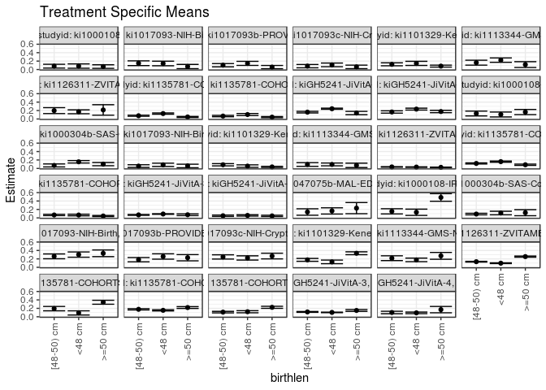

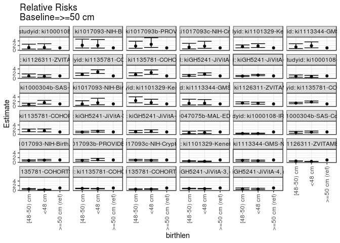

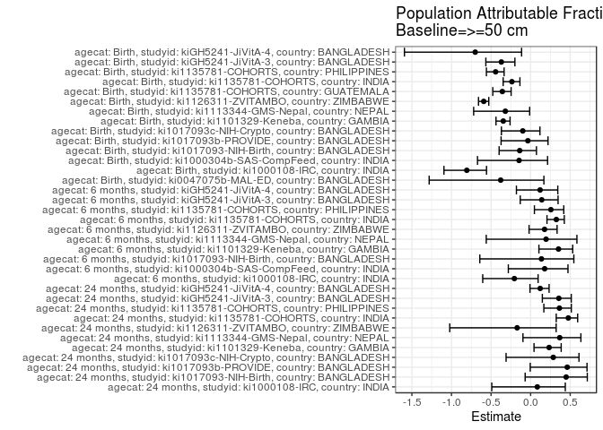

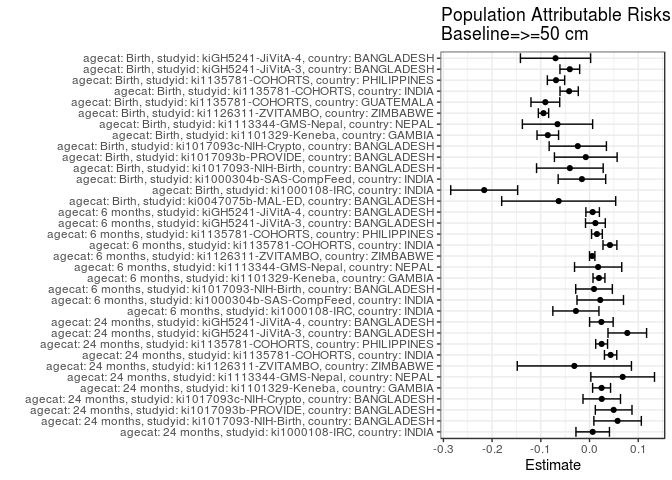

## Results Table

### Parameter: TSM

| agecat | studyid | country | intervention_level | baseline_level | estimate | ci_lower | ci_upper |
| --- | --- | --- | --- | --- | --- | --- | --- |
| Birth | ki0047075b-MAL-ED | BANGLADESH | >=50 cm | NA | 0.2307692 | 0.0982297 | 0.3633088 |
| Birth | ki0047075b-MAL-ED | BANGLADESH | <48 cm | NA | 0.1649485 | 0.0909189 | 0.2389780 |
| Birth | ki0047075b-MAL-ED | BANGLADESH | [48-50) cm | NA | 0.1392405 | 0.0627213 | 0.2157597 |
| Birth | ki1000108-IRC | INDIA | >=50 cm | NA | 0.4844817 | 0.3941815 | 0.5747818 |
| Birth | ki1000108-IRC | INDIA | <48 cm | NA | 0.1331002 | 0.0589459 | 0.2072545 |
| Birth | ki1000108-IRC | INDIA | [48-50) cm | NA | 0.1549023 | 0.0933586 | 0.2164460 |
| Birth | ki1000304b-SAS-CompFeed | INDIA | >=50 cm | NA | 0.1225963 | 0.0510530 | 0.1941396 |
| Birth | ki1000304b-SAS-CompFeed | INDIA | <48 cm | NA | 0.1148419 | 0.0724711 | 0.1572128 |
| Birth | ki1000304b-SAS-CompFeed | INDIA | [48-50) cm | NA | 0.0904985 | 0.0718005 | 0.1091966 |
| Birth | ki1017093-NIH-Birth | BANGLADESH | >=50 cm | NA | 0.3325550 | 0.2533940 | 0.4117160 |
| Birth | ki1017093-NIH-Birth | BANGLADESH | <48 cm | NA | 0.3024178 | 0.2401201 | 0.3647156 |
| Birth | ki1017093-NIH-Birth | BANGLADESH | [48-50) cm | NA | 0.2603183 | 0.2032373 | 0.3173993 |
| Birth | ki1017093b-PROVIDE | BANGLADESH | >=50 cm | NA | 0.2276432 | 0.1538049 | 0.3014815 |
| Birth | ki1017093b-PROVIDE | BANGLADESH | <48 cm | NA | 0.2568941 | 0.1933167 | 0.3204715 |
| Birth | ki1017093b-PROVIDE | BANGLADESH | [48-50) cm | NA | 0.1811178 | 0.1303246 | 0.2319110 |
| Birth | ki1017093c-NIH-Crypto | BANGLADESH | >=50 cm | NA | 0.2673973 | 0.1999106 | 0.3348841 |
| Birth | ki1017093c-NIH-Crypto | BANGLADESH | <48 cm | NA | 0.2223575 | 0.1721950 | 0.2725201 |
| Birth | ki1017093c-NIH-Crypto | BANGLADESH | [48-50) cm | NA | 0.2462788 | 0.1956709 | 0.2968868 |
| Birth | ki1101329-Keneba | GAMBIA | >=50 cm | NA | 0.3334739 | 0.2993735 | 0.3675742 |
| Birth | ki1101329-Keneba | GAMBIA | <48 cm | NA | 0.1287196 | 0.0858466 | 0.1715926 |
| Birth | ki1101329-Keneba | GAMBIA | [48-50) cm | NA | 0.1768896 | 0.1427494 | 0.2110298 |
| Birth | ki1113344-GMS-Nepal | NEPAL | >=50 cm | NA | 0.2716752 | 0.1907626 | 0.3525879 |
| Birth | ki1113344-GMS-Nepal | NEPAL | <48 cm | NA | 0.1763245 | 0.1341980 | 0.2184509 |
| Birth | ki1113344-GMS-Nepal | NEPAL | [48-50) cm | NA | 0.2161541 | 0.1594357 | 0.2728724 |
| Birth | ki1126311-ZVITAMBO | ZIMBABWE | >=50 cm | NA | 0.2540595 | 0.2405224 | 0.2675966 |
| Birth | ki1126311-ZVITAMBO | ZIMBABWE | <48 cm | NA | 0.0975496 | 0.0878269 | 0.1072723 |
| Birth | ki1126311-ZVITAMBO | ZIMBABWE | [48-50) cm | NA | 0.1332574 | 0.1240498 | 0.1424649 |
| Birth | ki1135781-COHORTS | GUATEMALA | >=50 cm | NA | 0.3447051 | 0.2977859 | 0.3916244 |
| Birth | ki1135781-COHORTS | GUATEMALA | <48 cm | NA | 0.0913035 | 0.0414860 | 0.1411211 |
| Birth | ki1135781-COHORTS | GUATEMALA | [48-50) cm | NA | 0.1929596 | 0.1413567 | 0.2445625 |

[output cut: 75 more lines]

### Parameter: E(Y)

| agecat | studyid | country | intervention_level | baseline_level | estimate | ci_lower | ci_upper |
| --- | --- | --- | --- | --- | --- | --- | --- |
| Birth | ki0047075b-MAL-ED | BANGLADESH | NA | NA | 0.1674419 | 0.1174176 | 0.2174661 |
| Birth | ki1000108-IRC | INDIA | NA | NA | 0.2682216 | 0.2212677 | 0.3151755 |
| Birth | ki1000304b-SAS-CompFeed | INDIA | NA | NA | 0.1069810 | 0.0760961 | 0.1378659 |
| Birth | ki1017093-NIH-Birth | BANGLADESH | NA | NA | 0.2921739 | 0.2549711 | 0.3293768 |
| Birth | ki1017093b-PROVIDE | BANGLADESH | NA | NA | 0.2199248 | 0.1846953 | 0.2551543 |
| Birth | ki1017093c-NIH-Crypto | BANGLADESH | NA | NA | 0.2432815 | 0.2116319 | 0.2749310 |
| Birth | ki1101329-Keneba | GAMBIA | NA | NA | 0.2477816 | 0.2256667 | 0.2698964 |
| Birth | ki1113344-GMS-Nepal | NEPAL | NA | NA | 0.2059282 | 0.1745993 | 0.2372572 |
| Birth | ki1126311-ZVITAMBO | ZIMBABWE | NA | NA | 0.1595572 | 0.1532418 | 0.1658725 |
| Birth | ki1135781-COHORTS | GUATEMALA | NA | NA | 0.2539683 | 0.2229196 | 0.2850169 |
| Birth | ki1135781-COHORTS | INDIA | NA | NA | 0.1769740 | 0.1674681 | 0.1864799 |
| Birth | ki1135781-COHORTS | PHILIPPINES | NA | NA | 0.1555709 | 0.1423748 | 0.1687670 |
| Birth | kiGH5241-JiVitA-3 | BANGLADESH | NA | NA | 0.1095259 | 0.1044047 | 0.1146471 |
| Birth | kiGH5241-JiVitA-4 | BANGLADESH | NA | NA | 0.0997496 | 0.0843744 | 0.1151247 |
| 6 months | ki1000108-IRC | INDIA | NA | NA | 0.1362468 | 0.1021125 | 0.1703810 |
| 6 months | ki1000304b-SAS-CompFeed | INDIA | NA | NA | 0.1240545 | 0.0993302 | 0.1487787 |
| 6 months | ki1017093-NIH-Birth | BANGLADESH | NA | NA | 0.0675676 | 0.0459314 | 0.0892038 |
| 6 months | ki1101329-Keneba | GAMBIA | NA | NA | 0.0549369 | 0.0427642 | 0.0671096 |
| 6 months | ki1113344-GMS-Nepal | NEPAL | NA | NA | 0.0905861 | 0.0668565 | 0.1143158 |
| 6 months | ki1126311-ZVITAMBO | ZIMBABWE | NA | NA | 0.0311423 | 0.0274303 | 0.0348542 |
| 6 months | ki1135781-COHORTS | INDIA | NA | NA | 0.1289375 | 0.1205453 | 0.1373297 |
| 6 months | ki1135781-COHORTS | PHILIPPINES | NA | NA | 0.0592812 | 0.0503704 | 0.0681920 |
| 6 months | kiGH5241-JiVitA-3 | BANGLADESH | NA | NA | 0.0859055 | 0.0807379 | 0.0910730 |
| 6 months | kiGH5241-JiVitA-4 | BANGLADESH | NA | NA | 0.0531809 | 0.0435210 | 0.0628408 |
| 24 months | ki1000108-IRC | INDIA | NA | NA | 0.0769231 | 0.0504429 | 0.1034032 |
| 24 months | ki1017093-NIH-Birth | BANGLADESH | NA | NA | 0.1283293 | 0.0960341 | 0.1606245 |
| 24 months | ki1017093b-PROVIDE | BANGLADESH | NA | NA | 0.1070812 | 0.0818727 | 0.1322897 |
| 24 months | ki1017093c-NIH-Crypto | BANGLADESH | NA | NA | 0.0875486 | 0.0630907 | 0.1120065 |
| 24 months | ki1101329-Keneba | GAMBIA | NA | NA | 0.1060038 | 0.0875152 | 0.1244923 |
| 24 months | ki1113344-GMS-Nepal | NEPAL | NA | NA | 0.1851852 | 0.1506144 | 0.2197560 |
| 24 months | ki1126311-ZVITAMBO | ZIMBABWE | NA | NA | 0.1830986 | 0.1463297 | 0.2198675 |
| 24 months | ki1135781-COHORTS | INDIA | NA | NA | 0.0908513 | 0.0826532 | 0.0990495 |
| 24 months | ki1135781-COHORTS | PHILIPPINES | NA | NA | 0.0682747 | 0.0582774 | 0.0782720 |
| 24 months | kiGH5241-JiVitA-3 | BANGLADESH | NA | NA | 0.2176282 | 0.2067563 | 0.2285000 |
| 24 months | kiGH5241-JiVitA-4 | BANGLADESH | NA | NA | 0.2013085 | 0.1867334 | 0.2158836 |

### Parameter: RR

| agecat | studyid | country | intervention_level | baseline_level | estimate | ci_lower | ci_upper |
| --- | --- | --- | --- | --- | --- | --- | --- |
| Birth | ki0047075b-MAL-ED | BANGLADESH | >=50 cm | >=50 cm | 1.0000000 | 1.0000000 | 1.0000000 |
| Birth | ki0047075b-MAL-ED | BANGLADESH | <48 cm | >=50 cm | 0.7147766 | 0.3448378 | 1.4815826 |
| Birth | ki0047075b-MAL-ED | BANGLADESH | [48-50) cm | >=50 cm | 0.6033755 | 0.2725003 | 1.3360061 |
| Birth | ki1000108-IRC | INDIA | >=50 cm | >=50 cm | 1.0000000 | 1.0000000 | 1.0000000 |
| Birth | ki1000108-IRC | INDIA | <48 cm | >=50 cm | 0.2747270 | 0.1527147 | 0.4942218 |
| Birth | ki1000108-IRC | INDIA | [48-50) cm | >=50 cm | 0.3197279 | 0.2059867 | 0.4962745 |
| Birth | ki1000304b-SAS-CompFeed | INDIA | >=50 cm | >=50 cm | 1.0000000 | 1.0000000 | 1.0000000 |
| Birth | ki1000304b-SAS-CompFeed | INDIA | <48 cm | >=50 cm | 0.9367487 | 0.6267780 | 1.4000142 |
| Birth | ki1000304b-SAS-CompFeed | INDIA | [48-50) cm | >=50 cm | 0.7381833 | 0.4332661 | 1.2576902 |
| Birth | ki1017093-NIH-Birth | BANGLADESH | >=50 cm | >=50 cm | 1.0000000 | 1.0000000 | 1.0000000 |
| Birth | ki1017093-NIH-Birth | BANGLADESH | <48 cm | >=50 cm | 0.9093769 | 0.6642044 | 1.2450480 |
| Birth | ki1017093-NIH-Birth | BANGLADESH | [48-50) cm | >=50 cm | 0.7827827 | 0.5666926 | 1.0812721 |
| Birth | ki1017093b-PROVIDE | BANGLADESH | >=50 cm | >=50 cm | 1.0000000 | 1.0000000 | 1.0000000 |
| Birth | ki1017093b-PROVIDE | BANGLADESH | <48 cm | >=50 cm | 1.1284946 | 0.7508654 | 1.6960431 |
| Birth | ki1017093b-PROVIDE | BANGLADESH | [48-50) cm | >=50 cm | 0.7956214 | 0.5186413 | 1.2205225 |
| Birth | ki1017093c-NIH-Crypto | BANGLADESH | >=50 cm | >=50 cm | 1.0000000 | 1.0000000 | 1.0000000 |
| Birth | ki1017093c-NIH-Crypto | BANGLADESH | <48 cm | >=50 cm | 0.8315623 | 0.5928861 | 1.1663215 |
| Birth | ki1017093c-NIH-Crypto | BANGLADESH | [48-50) cm | >=50 cm | 0.9210221 | 0.6652684 | 1.2750969 |
| Birth | ki1101329-Keneba | GAMBIA | >=50 cm | >=50 cm | 1.0000000 | 1.0000000 | 1.0000000 |
| Birth | ki1101329-Keneba | GAMBIA | <48 cm | >=50 cm | 0.3859960 | 0.2724949 | 0.5467731 |
| Birth | ki1101329-Keneba | GAMBIA | [48-50) cm | >=50 cm | 0.5304453 | 0.4263262 | 0.6599927 |
| Birth | ki1113344-GMS-Nepal | NEPAL | >=50 cm | >=50 cm | 1.0000000 | 1.0000000 | 1.0000000 |
| Birth | ki1113344-GMS-Nepal | NEPAL | <48 cm | >=50 cm | 0.6490267 | 0.4432439 | 0.9503472 |
| Birth | ki1113344-GMS-Nepal | NEPAL | [48-50) cm | >=50 cm | 0.7956340 | 0.5357137 | 1.1816637 |
| Birth | ki1126311-ZVITAMBO | ZIMBABWE | >=50 cm | >=50 cm | 1.0000000 | 1.0000000 | 1.0000000 |
| Birth | ki1126311-ZVITAMBO | ZIMBABWE | <48 cm | >=50 cm | 0.3839637 | 0.3429547 | 0.4298764 |
| Birth | ki1126311-ZVITAMBO | ZIMBABWE | [48-50) cm | >=50 cm | 0.5245124 | 0.4807657 | 0.5722398 |
| Birth | ki1135781-COHORTS | GUATEMALA | >=50 cm | >=50 cm | 1.0000000 | 1.0000000 | 1.0000000 |
| Birth | ki1135781-COHORTS | GUATEMALA | <48 cm | >=50 cm | 0.2648743 | 0.1508645 | 0.4650425 |
| Birth | ki1135781-COHORTS | GUATEMALA | [48-50) cm | >=50 cm | 0.5597815 | 0.4147077 | 0.7556053 |

[output cut: 75 more lines]

### Parameter: PAR

| agecat | studyid | country | intervention_level | baseline_level | estimate | ci_lower | ci_upper |
| --- | --- | --- | --- | --- | --- | --- | --- |
| Birth | ki0047075b-MAL-ED | BANGLADESH | >=50 cm | NA | -0.0633274 | -0.1803577 | 0.0537030 |
| Birth | ki1000108-IRC | INDIA | >=50 cm | NA | -0.2162601 | -0.2849721 | -0.1475481 |
| Birth | ki1000304b-SAS-CompFeed | INDIA | >=50 cm | NA | -0.0156154 | -0.0643885 | 0.0331578 |
| Birth | ki1017093-NIH-Birth | BANGLADESH | >=50 cm | NA | -0.0403811 | -0.1087918 | 0.0280296 |
| Birth | ki1017093b-PROVIDE | BANGLADESH | >=50 cm | NA | -0.0077184 | -0.0720603 | 0.0566235 |
| Birth | ki1017093c-NIH-Crypto | BANGLADESH | >=50 cm | NA | -0.0241159 | -0.0828875 | 0.0346558 |
| Birth | ki1101329-Keneba | GAMBIA | >=50 cm | NA | -0.0856923 | -0.1078067 | -0.0635779 |
| Birth | ki1113344-GMS-Nepal | NEPAL | >=50 cm | NA | -0.0657470 | -0.1378716 | 0.0063776 |
| Birth | ki1126311-ZVITAMBO | ZIMBABWE | >=50 cm | NA | -0.0945023 | -0.1050785 | -0.0839261 |
| Birth | ki1135781-COHORTS | GUATEMALA | >=50 cm | NA | -0.0907369 | -0.1202492 | -0.0612246 |
| Birth | ki1135781-COHORTS | INDIA | >=50 cm | NA | -0.0418570 | -0.0606225 | -0.0230914 |
| Birth | ki1135781-COHORTS | PHILIPPINES | >=50 cm | NA | -0.0688288 | -0.0865825 | -0.0510751 |
| Birth | kiGH5241-JiVitA-3 | BANGLADESH | >=50 cm | NA | -0.0405124 | -0.0607523 | -0.0202726 |
| Birth | kiGH5241-JiVitA-4 | BANGLADESH | >=50 cm | NA | -0.0698382 | -0.1419017 | 0.0022252 |
| 6 months | ki1000108-IRC | INDIA | >=50 cm | NA | -0.0280029 | -0.0753162 | 0.0193105 |
| 6 months | ki1000304b-SAS-CompFeed | INDIA | >=50 cm | NA | 0.0219919 | -0.0257415 | 0.0697253 |
| 6 months | ki1017093-NIH-Birth | BANGLADESH | >=50 cm | NA | 0.0092342 | -0.0283646 | 0.0468331 |
| 6 months | ki1101329-Keneba | GAMBIA | >=50 cm | NA | 0.0193576 | 0.0071257 | 0.0315895 |
| 6 months | ki1113344-GMS-Nepal | NEPAL | >=50 cm | NA | 0.0176695 | -0.0307949 | 0.0661339 |
| 6 months | ki1126311-ZVITAMBO | ZIMBABWE | >=50 cm | NA | 0.0054833 | -0.0000245 | 0.0109912 |
| 6 months | ki1135781-COHORTS | INDIA | >=50 cm | NA | 0.0418783 | 0.0276251 | 0.0561314 |
| 6 months | ki1135781-COHORTS | PHILIPPINES | >=50 cm | NA | 0.0151870 | 0.0041221 | 0.0262520 |
| 6 months | kiGH5241-JiVitA-3 | BANGLADESH | >=50 cm | NA | 0.0120610 | -0.0082322 | 0.0323543 |
| 6 months | kiGH5241-JiVitA-4 | BANGLADESH | >=50 cm | NA | 0.0063742 | -0.0075001 | 0.0202484 |
| 24 months | ki1000108-IRC | INDIA | >=50 cm | NA | 0.0065005 | -0.0279054 | 0.0409065 |
| 24 months | ki1017093-NIH-Birth | BANGLADESH | >=50 cm | NA | 0.0576222 | 0.0089037 | 0.1063407 |
| 24 months | ki1017093b-PROVIDE | BANGLADESH | >=50 cm | NA | 0.0495272 | 0.0118960 | 0.0871584 |
| 24 months | ki1017093c-NIH-Crypto | BANGLADESH | >=50 cm | NA | 0.0250486 | -0.0134555 | 0.0635528 |
| 24 months | ki1101329-Keneba | GAMBIA | >=50 cm | NA | 0.0247531 | 0.0063416 | 0.0431647 |
| 24 months | ki1113344-GMS-Nepal | NEPAL | >=50 cm | NA | 0.0680311 | 0.0026796 | 0.1333827 |
| 24 months | ki1126311-ZVITAMBO | ZIMBABWE | >=50 cm | NA | -0.0311871 | -0.1484218 | 0.0860476 |
| 24 months | ki1135781-COHORTS | INDIA | >=50 cm | NA | 0.0432587 | 0.0305849 | 0.0559324 |
| 24 months | ki1135781-COHORTS | PHILIPPINES | >=50 cm | NA | 0.0248424 | 0.0126759 | 0.0370088 |
| 24 months | kiGH5241-JiVitA-3 | BANGLADESH | >=50 cm | NA | 0.0775100 | 0.0378978 | 0.1171223 |
| 24 months | kiGH5241-JiVitA-4 | BANGLADESH | >=50 cm | NA | 0.0243003 | 0.0000995 | 0.0485011 |

### Parameter: PAF

| agecat | studyid | country | intervention_level | baseline_level | estimate | ci_lower | ci_upper |
| --- | --- | --- | --- | --- | --- | --- | --- |
| Birth | ki0047075b-MAL-ED | BANGLADESH | >=50 cm | NA | -0.3782051 | -1.2817707 | 0.1675546 |
| Birth | ki1000108-IRC | INDIA | >=50 cm | NA | -0.8062741 | -1.0950908 | -0.5572719 |
| Birth | ki1000304b-SAS-CompFeed | INDIA | >=50 cm | NA | -0.1459638 | -0.6710455 | 0.2141249 |
| Birth | ki1017093-NIH-Birth | BANGLADESH | >=50 cm | NA | -0.1382091 | -0.3981289 | 0.0733902 |
| Birth | ki1017093b-PROVIDE | BANGLADESH | >=50 cm | NA | -0.0350956 | -0.3731460 | 0.2197312 |
| Birth | ki1017093c-NIH-Crypto | BANGLADESH | >=50 cm | NA | -0.0991274 | -0.3693141 | 0.1177473 |
| Birth | ki1101329-Keneba | GAMBIA | >=50 cm | NA | -0.3458380 | -0.4375869 | -0.2599447 |
| Birth | ki1113344-GMS-Nepal | NEPAL | >=50 cm | NA | -0.3192714 | -0.7197049 | -0.0120789 |
| Birth | ki1126311-ZVITAMBO | ZIMBABWE | >=50 cm | NA | -0.5922788 | -0.6585038 | -0.5286981 |
| Birth | ki1135781-COHORTS | GUATEMALA | >=50 cm | NA | -0.3572765 | -0.4780284 | -0.2463897 |
| Birth | ki1135781-COHORTS | INDIA | >=50 cm | NA | -0.2365149 | -0.3470033 | -0.1350892 |
| Birth | ki1135781-COHORTS | PHILIPPINES | >=50 cm | NA | -0.4424274 | -0.5584135 | -0.3350736 |
| Birth | kiGH5241-JiVitA-3 | BANGLADESH | >=50 cm | NA | -0.3698890 | -0.5657080 | -0.1985606 |
| Birth | kiGH5241-JiVitA-4 | BANGLADESH | >=50 cm | NA | -0.7001355 | -1.5942110 | -0.1141965 |
| 6 months | ki1000108-IRC | INDIA | >=50 cm | NA | -0.2055304 | -0.6051052 | 0.0945742 |
| 6 months | ki1000304b-SAS-CompFeed | INDIA | >=50 cm | NA | 0.1772760 | -0.2816767 | 0.4718834 |
| 6 months | ki1017093-NIH-Birth | BANGLADESH | >=50 cm | NA | 0.1366667 | -0.6418943 | 0.5460460 |
| 6 months | ki1101329-Keneba | GAMBIA | >=50 cm | NA | 0.3523600 | 0.1046741 | 0.5315253 |
| 6 months | ki1113344-GMS-Nepal | NEPAL | >=50 cm | NA | 0.1950572 | -0.5606777 | 0.5848387 |
| 6 months | ki1126311-ZVITAMBO | ZIMBABWE | >=50 cm | NA | 0.1760740 | -0.0197699 | 0.3343066 |
| 6 months | ki1135781-COHORTS | INDIA | >=50 cm | NA | 0.3247951 | 0.2066676 | 0.4253333 |
| 6 months | ki1135781-COHORTS | PHILIPPINES | >=50 cm | NA | 0.2561858 | 0.0480269 | 0.4188286 |
| 6 months | kiGH5241-JiVitA-3 | BANGLADESH | >=50 cm | NA | 0.1403987 | -0.1310842 | 0.3467202 |
| 6 months | kiGH5241-JiVitA-4 | BANGLADESH | >=50 cm | NA | 0.1198579 | -0.1793841 | 0.3431740 |
| 24 months | ki1000108-IRC | INDIA | >=50 cm | NA | 0.0845070 | -0.4909232 | 0.4378467 |
| 24 months | ki1017093-NIH-Birth | BANGLADESH | >=50 cm | NA | 0.4490185 | -0.0691897 | 0.7160648 |
| 24 months | ki1017093b-PROVIDE | BANGLADESH | >=50 cm | NA | 0.4625203 | -0.0050565 | 0.7125690 |
| 24 months | ki1017093c-NIH-Crypto | BANGLADESH | >=50 cm | NA | 0.2861111 | -0.3102198 | 0.6110291 |
| 24 months | ki1101329-Keneba | GAMBIA | >=50 cm | NA | 0.2335118 | 0.0429686 | 0.3861182 |
| 24 months | ki1113344-GMS-Nepal | NEPAL | >=50 cm | NA | 0.3673682 | -0.0969073 | 0.6351351 |
| 24 months | ki1126311-ZVITAMBO | ZIMBABWE | >=50 cm | NA | -0.1703297 | -1.0218429 | 0.3225628 |
| 24 months | ki1135781-COHORTS | INDIA | >=50 cm | NA | 0.4761477 | 0.3235935 | 0.5942955 |
| 24 months | ki1135781-COHORTS | PHILIPPINES | >=50 cm | NA | 0.3638592 | 0.1670729 | 0.5141530 |
| 24 months | kiGH5241-JiVitA-3 | BANGLADESH | >=50 cm | NA | 0.3561580 | 0.1481498 | 0.5133739 |
| 24 months | kiGH5241-JiVitA-4 | BANGLADESH | >=50 cm | NA | 0.1207116 | -0.0082559 | 0.2331827 |